# Time Series Analysis in R

2018-05-22 13:25

Lately I’ve been looking to explore time-series modeling and to get more practice with manipulating data in R. Luckily, a dataset on Kaggle provided me the opportunity to do both of these things. Attempting to predict future sale volume of items in stores (from 1-C russian store sales dataset) gave me the chance to apply the theoretical knowledge I’ve been studying of time-series analysis (ARIMA in particual). Additionally, I was able to get more comfortable with dplyr and lubridate in the process.

The variable of interest here was a daily count of sales for each item-store combo, equating to over 2 million rows of data. The process I took was to:

-aggregate sales data into monthly counts (this is what Kaggle contest is looking for) -separate each store-item combo out into its own time-series. -Explore how appropriate an ARIMA model is and if differentiation is called for -Find a model which could generalize the data for each combo effectively -Run the function to predict next months sales for the store-item combo.

Regardless, this was great practice, gave me a better understanding of working with time-series, and in particular how to judge stationarity and appropriateness for ARIMA.

NOTE: many of the lines are commented out.. Most of these were excluded from my final knit as compuation times were a bit excessive for some of the loops and functions I ended up using.

```r
knitr::opts_chunk$set(echo = TRUE)
library(tidyverse)
library(xts)
library(lubridate)
library(tseries)
```

## Time Series Analysis in R

Exploring daily sales data of software firm 1C. This dataset was obtained from Kaggle and is used for the final project of the Coursera “How to win a data science competition” coutse. NOTE: I did not take this course!

First to import the data and see how it looks:

```r
#train data
train <- read.csv('data/train.csv', stringsAsFactors = FALSE)

#test data & Kaggle sample sub
test <- read.csv('data/test.csv')
sample_sub <- read.csv('data/sample_submission.csv')

#additional data included
items <- read.csv('data/items.csv')
categories <- read.csv('data/item_categories.csv')
shops <- read.csv("data/shops.csv")
```

## Describe the datasets

Initial exploration to check data types, sizes, etc.

```r
dim(train)
```

```
## [1] 2935849       6
```

```r
head(train)
```

```
##         date date_block_num shop_id item_id item_price item_cnt_day
## 1 02.01.2013              0      59   22154     999.00            1
## 2 03.01.2013              0      25    2552     899.00            1
## 3 05.01.2013              0      25    2552     899.00           -1
## 4 06.01.2013              0      25    2554    1709.05            1
## 5 15.01.2013              0      25    2555    1099.00            1
## 6 10.01.2013              0      25    2564     349.00            1
```

```r
dim(test)
```

```
## [1] 214200      3
```

```r
head(test)
```

```
##   ID shop_id item_id
## 1  0       5    5037
## 2  1       5    5320
## 3  2       5    5233
## 4  3       5    5232
## 5  4       5    5268
## 6  5       5    5039
```

```r
head(sample_sub)
```

```
##   ID item_cnt_month
## 1  0            0.5
## 2  1            0.5
## 3  2            0.5
## 4  3            0.5
## 5  4            0.5
## 6  5            0.5
```

So, looks as if we’re to predict the ‘item_cnt_month’ based upon ‘shop_id’ and ‘item_id’.. A few things this informs us:

Need to craft a ‘daily sales’item_cnt_day’ varible in the train set into a monthly sale count to have an appropriate dependant variable for model fitting. This should be done by

-Aggregate daily sales into monthy, split by shop_id and item_id.

Once this is done, we have two other variables of interest in the train: -date : we’ll perform some time-series analysis here -price: I’m, sure there is some coreelation between this and monthly sales.

So, first step is to create the monthly sales variable in train per shop/item. Then we can explore trends and seasonality in the time-series.

```r
#First set year variable and edit typeas
train$year <- substr(train$date, 7, 10)
train$year <- as.numeric(train$year)

train$month <- substr(train$date, 4, 5)
train$month <- as.numeric(train$month)

train$date <- as.Date(train$date, "%d.%m.%Y")

sapply(train, class)
```

```
##           date date_block_num        shop_id        item_id     item_price
##         "Date"      "integer"      "integer"      "integer"      "numeric"
##   item_cnt_day           year          month
##      "numeric"      "numeric"      "numeric"
```

Should have done this first probably :/ lets check for missing values real quick.

```r
sapply(train, function(x) sum(is.na(x)))
```

```
##           date date_block_num        shop_id        item_id     item_price
##              0              0              0              0              0
##   item_cnt_day           year          month
##              0              0              0
```

Love Kaggle for that. Lets divert from the train for a second and add the next block count, year, and month to the test set. We know it’s the next year/month occuring right after the end of the train set, which is october 2015.

```r
#date <- as.Date("01.11.2015", "%d.%m.%Y")

#for (i in 1:nrow(test)){
#  test[i,4] = 35
#  test[i, 5] = 2015
#  test[i, 6] = 11
#}


#colnames(test)[4:6] <- c('date_block_num', 'year', 'month')
```

Lets also split out the needed data into a train set which accounts for monthly sales rather than daily.

```r
#train$my <- floor_date(train$date, "month")

df_train <- train %>% group_by(date_block_num, shop_id, item_id, year, month) %>%
  summarize(item_cnt_month = sum(item_cnt_day))
```

## Basic Median fit

```r
#basic <- df_train %>% group_by(shop_id, item_id) %>%
#  summarize(mean_count = median(item_cnt_month))


#overall_mean <- mean(basic$mean_count)

#basic_test <- test %>% select(ID, shop_id, item_id)

#basic_test <- merge(x = basic_test, y = basic, by = c("shop_id", "item_id"), all.x = TRUE)
#basic_test$mean_count[is.na(basic_test$mean_count)] <- overall_mean

#preds = basic_test$mean_count
#sample_sub$item_cnt_month = preds

#write.csv(sample_sub, file = "D://projects/kaggle/time_series/basic_af.csv", row.names = #FALSE)
```

So back to work on the time series.. lets figure out how to set it up by exploring one or two specific shop-item combos.

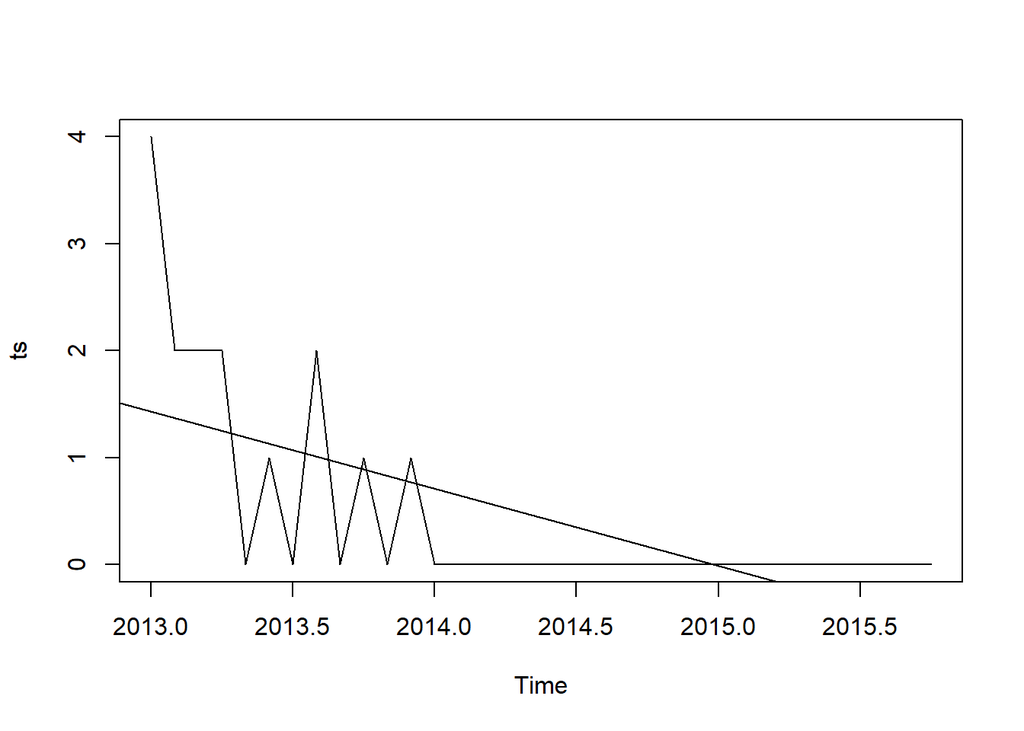

```r
ts_train <- train %>% group_by(date_block_num, shop_id, item_id) %>%
  summarize(item_cnt_month = sum(item_cnt_day))# %>%
  #mutate(ts = xts(item_cnt_month, order.by = as.Date(ts_train$date)))



### TRIAL HERE
ts_test <- subset(ts_train, ts_train$shop_id == 10 & ts_train$item_id == 1871)

ts <- rnorm(34, m = 0, sd = 0)
ts <- ts(ts, start = 2013, frequency = 12)


for (i in 1:34){
  if(i %in% ts_test$date_block_num){
    j <- which(ts_test$date_block_num == i)
    num <- ts_test[j,4]
    ts[i] <- as.numeric(num)
  }
}


plot(ts)
abline(reg = lm(ts~time(ts)))
```

```r
### END HERE
```

I’m going to focus on checking the time-series for trend/seasonality first. Performing ARIMA requires stationary data. lets make sure the cycle is correct.

```r
cycle(ts)
```

```
##      Jan Feb Mar Apr May Jun Jul Aug Sep Oct Nov Dec
## 2013   1   2   3   4   5   6   7   8   9  10  11  12
## 2014   1   2   3   4   5   6   7   8   9  10  11  12
## 2015   1   2   3   4   5   6   7   8   9  10
```

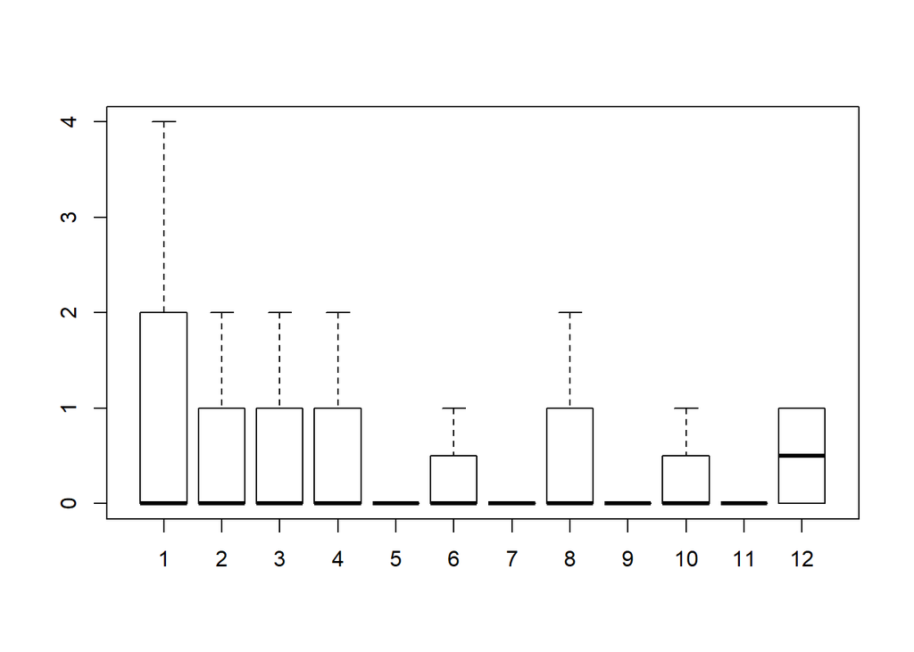

```r
boxplot(ts~cycle(ts))
```

Variance remains the same so no need to log.. additional, log doesn’t act nicely with 0… Our sale items are dropping, but not quite negative infinity.

```r
adf.test(ts, alternative = "stationary", k = 0)
```

```
##
##  Augmented Dickey-Fuller Test
##
## data:  ts
## Dickey-Fuller = -6.3398, Lag order = 0, p-value = 0.01
## alternative hypothesis: stationary
```

```r
adf.test(diff(ts), alternative="stationary", k=0)
```

```
##
##  Augmented Dickey-Fuller Test
##
## data:  diff(ts)
## Dickey-Fuller = -15.55, Lag order = 0, p-value = 0.01
## alternative hypothesis: stationary
```

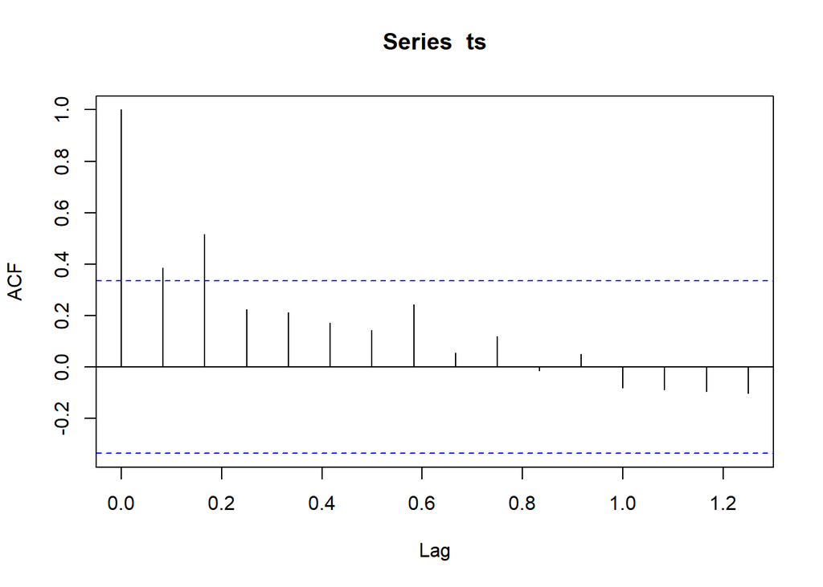

```r
acf(ts)
```

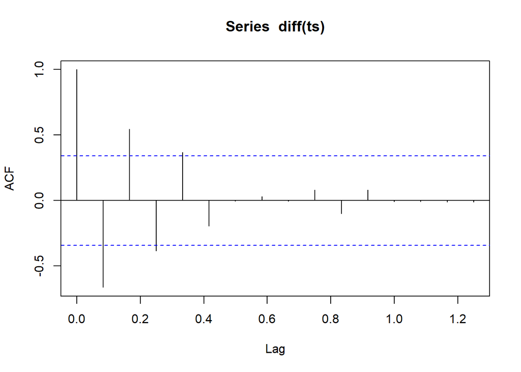

```r
acf(diff(ts))
```

I’m voting on the differentiated version. lets check PACF as well

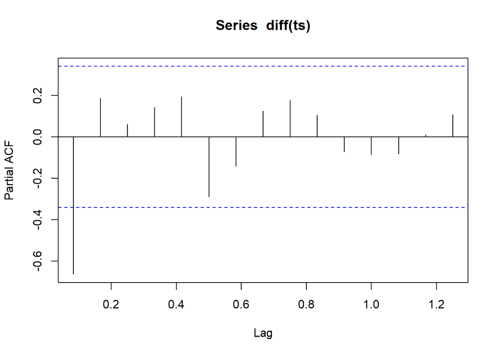

```r
pacf(diff(ts))
```

Based on the plots, I think it looks like we have an ARIMA model setup of a 1 in auto-regession and 1 or 2 in moving average.. Lets go with the 2 here so

AR, I, MA ->(1,1,2)

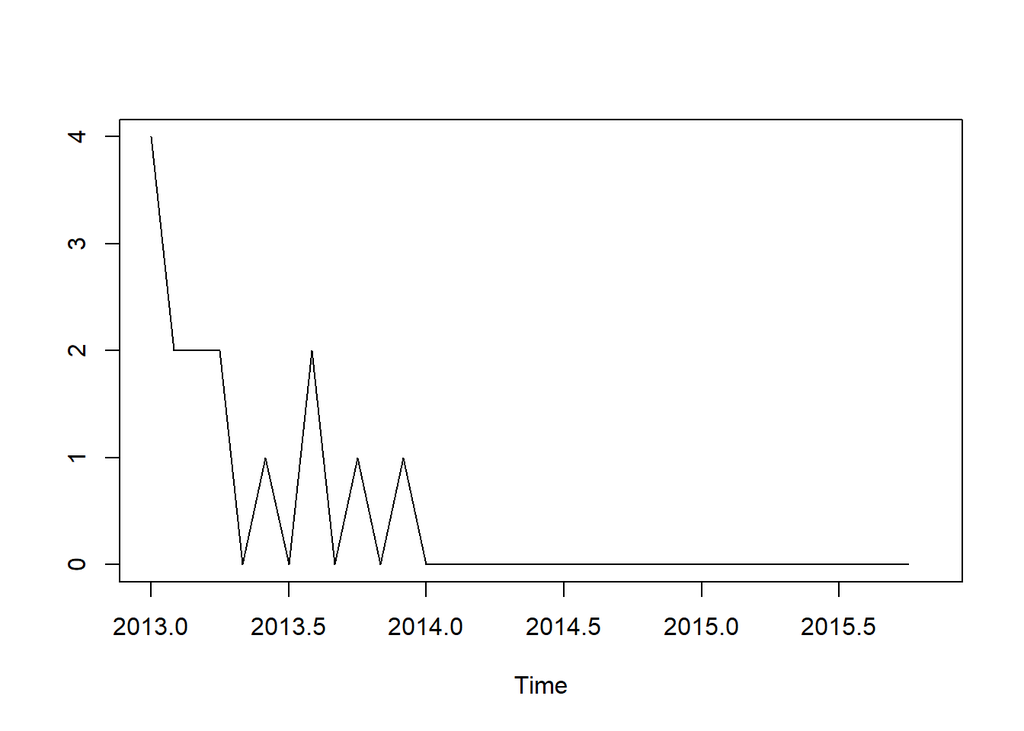

```r
fit112 <- arima(ts, order = c(1, 1, 2))

pred112 <- predict(fit112)
ts.plot(ts, pred112$pred, lty = c(1,3))
```

```r
pred112$pred
```

```
##                Nov
## 2015 -5.093003e-09
```

Aright.. its looks good.. an estimate of very very very close to 0. Lets find a shop-item with more sales and see how this same setup does.

```r
#ts_test <- subset(ts_train, ts_train$shop_id == 31 & ts_train$item_id == 20949)

#ts <- rnorm(34, m = 0, sd = 0)
#ts <- ts(ts, start = 2013, frequency = 12)


#for (i in 1:34){
#  if(i %in% ts_test$date_block_num){
#    j <- which(ts_test$date_block_num == i)
#    num <- ts_test[j,4]
#    ts[i] <- as.numeric(num)
#  }
#}


#plot(ts)
#abline(reg = lm(ts~time(ts)))

#boxplot(ts~cycle(ts))

#adf.test(ts, alternative = "stationary", k = 0)
#adf.test(diff(ts), alternative="stationary", k=0)

#acf(diff(ts))

#pacf(diff(ts))

#fit011 <- arima(ts, order = c(0, 1, 1))

#pred011 <- predict(fit011)


#ts.plot(ts, pred011$pred, lty = c(1,3))

#pred011$pred
```

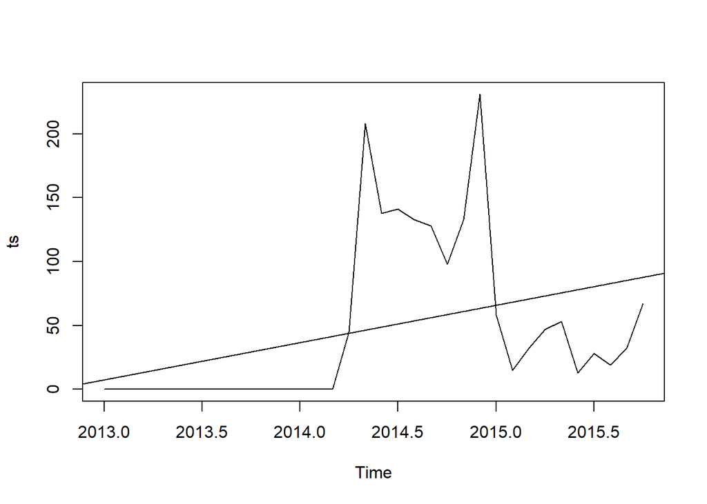

```r
ts_test <- subset(ts_train, ts_train$shop_id == 48 & ts_train$item_id == 20949)

ts <- rnorm(34, m = 0, sd = 0)
ts <- ts(ts, start = 2013, frequency = 12)


for (i in 1:34){
  if(i %in% ts_test$date_block_num){
    j <- which(ts_test$date_block_num == i)
    num <- ts_test[j,4]
    ts[i+1] <- as.numeric(num)
  }
}


plot(ts)
abline(reg = lm(ts~time(ts)))
```

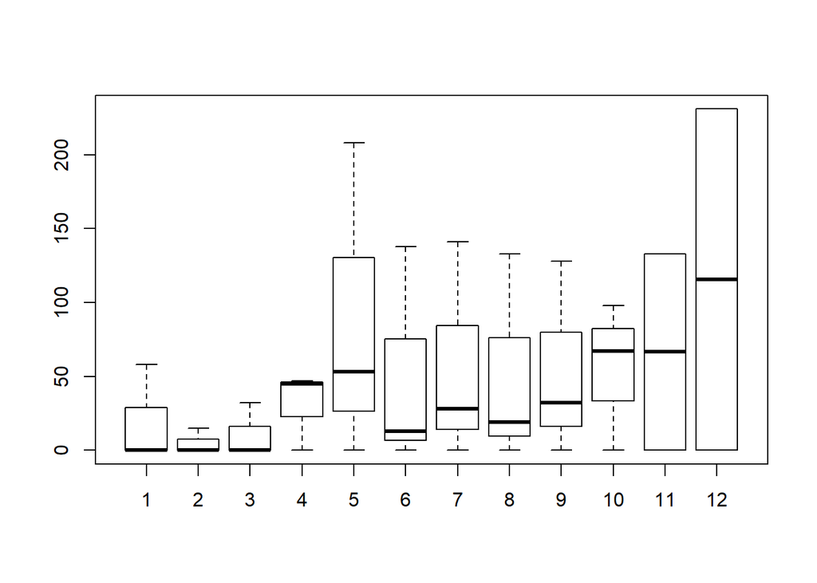

```r
boxplot(ts~cycle(ts))
```

```r
adf.test(ts, alternative = "stationary", k = 0)
```

```
##
##  Augmented Dickey-Fuller Test
##
## data:  ts
## Dickey-Fuller = -2.4661, Lag order = 0, p-value = 0.3924
## alternative hypothesis: stationary
```

```r
adf.test(diff(ts), alternative="stationary", k=0)
```

```
##
##  Augmented Dickey-Fuller Test
##
## data:  diff(ts)
## Dickey-Fuller = -6.2593, Lag order = 0, p-value = 0.01
## alternative hypothesis: stationary
```

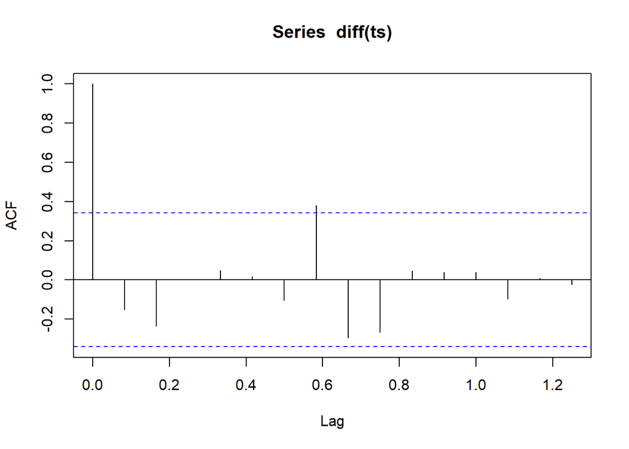

```r
acf(diff(ts))
```

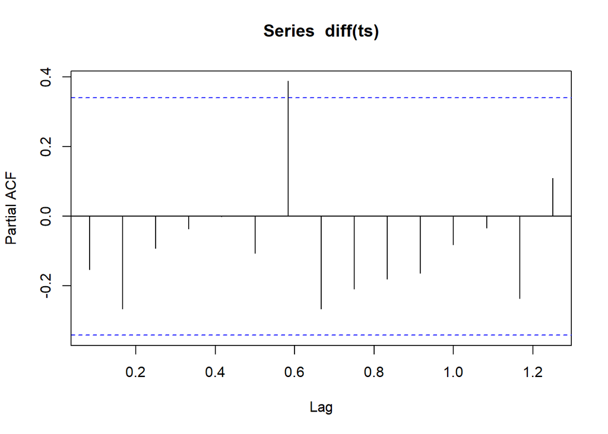

```r
pacf(diff(ts))
```

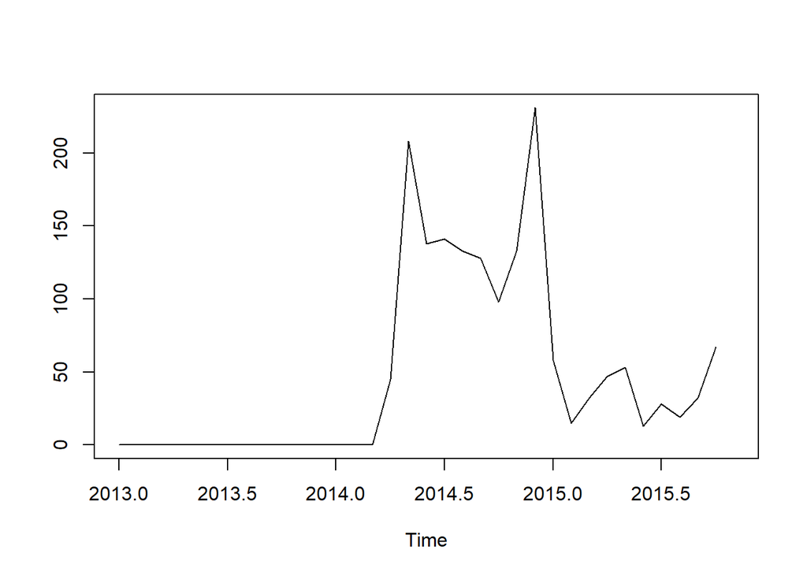

```r
fit112 <- arima(ts, order = c(1, 1, 2))

pred112 <- predict(fit112)


ts.plot(ts, pred112$pred, lty = c(1,3))
```

```r
pred112$pred
```

```
##           Nov
## 2015 50.25803
```

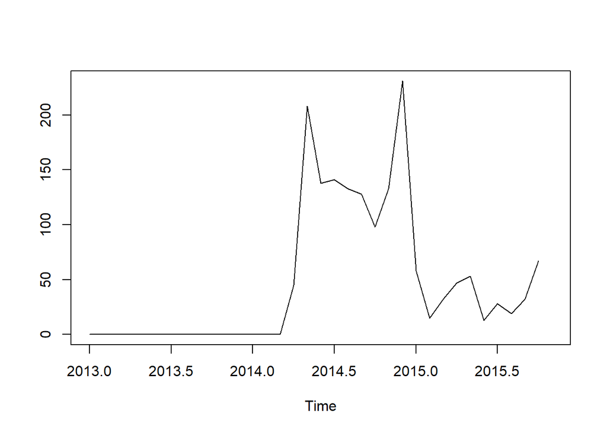

```r
fit011 <- arima(ts, order = c(0, 1, 1))

pred011 <- predict(fit011)


ts.plot(ts, pred011$pred, lty = c(1,3))
```

```r
pred011$pred
```

```
##           Nov
## 2015 55.73907
```

Exciting! We see sales increasing slightly in the past few months in this subset after a dip, and the model accounts for that and estimates 50 items sold for the next month in the cycle..

I personal think the (1, 1, 2) ARIMA seems to fit better as a generalization if I’m looking for one to fit all possible shop-item combo’s. Speaking of, I need to write up a function to run through the store item combos and fit the model/report it to a list.. I’ll finally take the list and reorder it to the sample submission and test the fits on kaggle.

```r
get_preds <- function(){
  #get store id and item id from test data

  preds <-list()

  for(i in 1:nrow(test)){
    store_id <- test[i,2]
    items_id <- test[i, 3]

    ts_test <- subset(ts_train, ts_train$shop_id == store_id & ts_train$item_id == items_id)

    ts <- rnorm(34, m = 0, sd = 0)
    ts <- ts(ts, start = 2013, frequency = 12)

    for (k in 0:33){
      if(k %in% ts_test$date_block_num){
        j <- which(ts_test$date_block_num == k)
        num <- ts_test[j,4]
        ts[k+1] <- as.numeric(num)
      }
    }
    if (max(ts) <= 0){
      preds[i] <- 0
    }

    else{
    #try(fit <- arima(ts, order = c(1, 1, 2), method = "ML"))
      ##CHANGE THIS TO CHANGE MODEL
      fit <- HoltWinters(ts, alpha = .35, beta = FALSE, gamma = FALSE)

      pred <- predict(fit)
      preds[i] <- pred
    }

    if (i %% 1000 == 0){
      print(i)
    }
  }
}
#get_preds()
```

Alright, we should have a list of predictions from the ARIMA model.. Lets check a few then move them to their proper column in the sample submission from KAggle.

NOTE: I came back to this after the first few submissions and gave exponential smoothing a try.. SO while my ARIMA is commented out, this was the primaryt exploration I performed.Exponential smoothing was slighltly better than ARIMA- (0.1 decrease in root mean square error)!

```r
#clipper<- function(preds, UB=11, LB=0) pmax( LB, pmin( preds, UB))
#clipped_preds <- clipper(preds)

#print(preds[1])
#print(preds[100])
#print(preds[100000])

#for (i in 1:nrow(sample_sub)){
#  sample_sub[i,2] <- clipped_preds[i]
#}

#sample_sub$item_cnt_month <- round(sample_sub$item_cnt_month)
#sample_sub[1:10,]
```

All thats left is to write it out for submission:

```r
#write.csv(sample_sub, file = "D://projects/kaggle/time_series/exp_smooth_11_clip.csv", row.names = FALSE)
```

## Kaggle Results

Top 28% of contestants (146/531)!!. I’m happy with it for my first time running a time series model. This model may also be running into trouble due to over-generalizing the auto-regressive and moving average values for each shop-item combo.. It’s definately not the strongest for each individual combination. I think that is at least partially the reasin the exponential smoothing method performs more accurately for the data.

Regardless, I’m happy with my first epxlorations into time-series analysis in R. A root mean squared error of only 1.06 is pretty decent for predicting how many items a store will sell based on only 34 months of data. Including some more details about the items (like category or price) could possibly enhance this even more I’m sure.

As my goal here was to fit and test a time-series model though, I’d say this is successful.